# Pertemuan 3 - Regresi dengan Peubah Lag

## Impor Data

```r
library(readxl)
data1 <- read_excel("C:\\Users\\aisya\\Documents\\MATKUL\\Semester 5\\MPDW\\data_regresi_deret_waktu.xlsx")
data2 <- read_excel("C:\\Users\\aisya\\Documents\\MATKUL\\Semester 5\\MPDW\\Sales_Advertising_Data.xlsx")

str(data1)
```

```
## tibble [20 × 3] (S3: tbl_df/tbl/data.frame)
##  $ Period      : num [1:20] 1 2 3 4 5 6 7 8 9 10 ...
##  $ Market_share: num [1:20] 3.63 4.2 3.33 4.54 2.89 4.87 4.9 5.29 6.18 7.2 ...
##  $ Price       : num [1:20] 0.97 0.95 0.99 0.91 0.98 0.9 0.89 0.86 0.85 0.82 ...
```

```r
str(data2)
```

```
## tibble [40 × 3] (S3: tbl_df/tbl/data.frame)
##  $ Year       : num [1:40] 1975 1976 1977 1978 1979 ...
##  $ Sales      : num [1:40] 11.7 12 12.3 12.8 13.1 13.6 13.9 14.4 14.7 15.3 ...
##  $ Advertising: num [1:40] 9.4 9.6 10 10.4 10.8 10.9 11.7 12.2 12.5 12.9 ...
```

```r
data1
```

```
## # A tibble: 20 × 3
##    Period Market_share Price
##     <dbl>        <dbl> <dbl>
##  1      1         3.63  0.97
##  2      2         4.2   0.95
##  3      3         3.33  0.99
##  4      4         4.54  0.91
##  5      5         2.89  0.98
##  6      6         4.87  0.9
##  7      7         4.9   0.89
##  8      8         5.29  0.86
##  9      9         6.18  0.85
## 10     10         7.2   0.82
## 11     11         7.25  0.79
## 12     12         6.09  0.83
## 13     13         6.8   0.81
## 14     14         8.65  0.77
## 15     15         8.43  0.76
## 16     16         8.29  0.8
## 17     17         7.18  0.83
## 18     18         7.9   0.79
## 19     19         8.45  0.76
## 20     20         8.23  0.78
```

```r
data2
```

```
## # A tibble: 40 × 3
##     Year Sales Advertising
##    <dbl> <dbl>       <dbl>
##  1  1975  11.7         9.4
##  2  1976  12           9.6
##  3  1977  12.3        10
##  4  1978  12.8        10.4
##  5  1979  13.1        10.8
##  6  1980  13.6        10.9
##  7  1981  13.9        11.7
##  8  1982  14.4        12.2
##  9  1983  14.7        12.5
## 10  1984  15.3        12.9
## # ℹ 30 more rows
```

# Distributed Lag Data 1 (Market Share ~ Price)

## Pembagian Data

```r
#SPLIT DATA
train1<-data1[1:15,]
test1<-data1[16:20,]
```

```r
#data time series
train1.ts<-ts(train1)
test1.ts<-ts(test1)
data1.ts<-ts(data1)
```

[figure not shown]

- **distributed lag model** : Variabel Dependen Y dipengaruhi oleh lag dari variabel independen X ( Xt-1, Xt-2 , dst)
- **Autoregresive model** : Variabel Dependen Y dipengaruhi oleh lag dirinya sendiri (Yt-1, Yt-2, dst) dan X sekarang (Xt)

## Model Koyck

Model Koyck didasarkan pada asumsi bahwa semakin jauh jarak lag peubah independen dari periode sekarang maka semakin kecil pengaruh peubah lag terhadap peubah dependen.

Koyck mengusulkan suatu metode untuk menduga model dinamis distributed lag dengan mengasumsikan bahwa semua koefisien $\beta$ mempunyai tanda sama.

Model kyock merupakan jenis paling umum dari model infinite distributed lag dan juga dikenal sebagai geometric lag

$$y_t=a(1-\lambda)+\beta_0X_t+\beta_1Z_t+\lambda Y_{t-1}+V_t$$

dengan
$$V_t=u_t-\lambda
u_{t-1}$$

### Pemodelan

Fungsi `koyckDlm()` akan menerapkan model lag terdistribusi dengan transformasi Koyck satu prediktor. Nilai `x` dan `y` tidak perlu sebagai objek *time series* (`ts`). `intercept` dapat dibuat `TRUE` untuk memasukkan intersep ke dalam model.

```r
#MODEL KOYCK
model1.koyck <- koyckDlm(x = train1$Price, y = train1$Market_share)
summary(model1.koyck)
```

```
##
## Call:
## "Y ~ (Intercept) + Y.1 + X.t"
##
## Residuals:
##     Min      1Q  Median      3Q     Max
## -0.9997 -0.3171  0.0652  0.2586  1.1063
##
## Coefficients:
##             Estimate Std. Error t value Pr(>|t|)
## (Intercept)  15.4328    14.7611   1.046    0.318
## Y.1           0.3651     0.5152   0.709    0.493
## X.t         -13.4703    13.8869  -0.970    0.353
##
## Residual standard error: 0.599 on 11 degrees of freedom
## Multiple R-Squared: 0.9037,  Adjusted R-squared: 0.8861
## Wald test: 37.92 on 2 and 11 DF,  p-value: 1.16e-05
##
## Diagnostic tests:
## NULL
##
##                             alpha      beta       phi
## Geometric coefficients:  24.30938 -13.47028 0.3651498
```

```r
AIC(model1.koyck)
```

```
## [1] 30.00231
```

```r
BIC(model1.koyck)
```

```
## [1] 32.55853
```

### Peramalan dan Akurasi

Berikut adalah hasil peramalan y untuk 5 periode kedepan menggunakan model koyck

```r
fore1.koyck <- forecast(model = model1.koyck, x=test1$Price, h=5)
fore1.koyck
```

```
## $forecasts
## [1] 7.734805 7.076847 7.375405 7.888531 7.806494
##
## $call
## forecast.koyckDlm(model = model1.koyck, x = test1$Price, h = 5)
##
## attr(,"class")
## [1] "forecast.koyckDlm" "dLagM"
```

```r
mape1.koyck <- MAPE(fore1.koyck$forecasts, test1$Market_share)
mape1.koyck #data test
```

```
## [1] 0.05312954
```

```r
#akurasi data training
GoF(model1.koyck)
```

```
##               n       MAE         MPE       MAPE      sMAPE      MASE       MSE
## model1.koyck 14 0.4215632 -0.01898878 0.08448088 0.08112884 0.4555545 0.2818772
##                  MRAE     GMRAE
## model1.koyck 1.457091 0.5463437
```

## Regression with Distributed Lag

Fungsi `dlm()` akan menerapkan model lag terdistribusi dengan satu atau lebih prediktor. Nilai `x` dan `y` tidak perlu sebagai objek *time series* (`ts`). $q$ adalah integer yang mewakili panjang *lag* yang terbatas.

### Pemodelan (Lag=2)

```r
model1.dlm <- dlm(x = train1$Price,y = train1$Market_share , q = 2)
summary(model1.dlm)
```

```
##
## Call:
## lm(formula = model.formula, data = design)
##
## Residuals:
##      Min       1Q   Median       3Q      Max
## -0.55526 -0.24858 -0.08971  0.20176  0.65633
##
## Coefficients:
##              Estimate Std. Error t value Pr(>|t|)
## (Intercept)  26.29549    1.69541  15.510 8.44e-08 ***
## x.t         -24.13651    4.05335  -5.955 0.000214 ***
## x.1          -0.00163    3.20631  -0.001 0.999606
## x.2           0.34290    4.21417   0.081 0.936929
## ---
## Signif. codes:  0 '***' 0.001 '**' 0.01 '*' 0.05 '.' 0.1 ' ' 1
##
## Residual standard error: 0.4366 on 9 degrees of freedom
## Multiple R-squared:  0.9553, Adjusted R-squared:  0.9404
## F-statistic: 64.06 on 3 and 9 DF,  p-value: 2.151e-06
##
## AIC and BIC values for the model:
##        AIC     BIC
## 1 20.56206 23.3868
```

```r
AIC(model1.dlm)
```

```
## [1] 20.56206
```

```r
BIC(model1.dlm)
```

```
## [1] 23.3868
```

Dari hasil diatas, didapat bahwa $P-value$ dari intercept dan $x_{t}<0.05$. Hal ini menunjukkan bahwa intercept dan $x_{t}$ berpengaruh signifikan terhadap $y$. Adapun model keseluruhan yang terbentuk adalah sebagai berikut

$$\hat{Y_t}=26.29549-24.13651X_t-0.00163X_{t-1}+0.34290X_{t-2}$$

### Peramalan dan Akurasi

Berikut merupakan hasil peramalan $y$ untuk 5 periode kedepan

```r
fore1.dlm <- forecast(model = model1.dlm, x=test1$Price, h=5)
fore1.dlm
```

```
## $forecasts
## [1] 7.249082 6.521493 7.500621 8.235068 7.738671
##
## $call
## forecast.dlm(model = model1.dlm, x = test1$Price, h = 5)
##
## attr(,"class")
## [1] "forecast.dlm" "dLagM"
```

```r
mape1.dlm <- MAPE(fore1.dlm$forecasts, test1$Market_share)
mape1.dlm
```

```
## [1] 0.0705934
```

```r
#akurasi data training
GoF(model1.dlm)
```

```
##             n       MAE           MPE       MAPE      sMAPE      MASE       MSE
## model1.dlm 13 0.3009786 -0.0004896023 0.05451787 0.05541524 0.3236329 0.1319396
##                MRAE     GMRAE
## model1.dlm 1.474088 0.3515233
```

### *Lag* Optimum

```r
#penentuan lag optimum
finiteDLMauto(formula = Market_share ~ Price,
              data = data.frame(train1), q.min = 1, q.max = 10,
              model.type = "dlm", error.type = "AIC", trace = TRUE)
```

```
##    q - k    MASE      AIC      BIC   GMRAE    MBRAE R.Adj.Sq  Ljung-Box
## 7      7 0.00000     -Inf     -Inf 0.00000  0.00000      NaN        NaN
## 8      8 0.00000     -Inf     -Inf 0.00000  0.00000      NaN        NaN
## 9      9 0.00000     -Inf     -Inf 0.00000  0.00000      NaN        NaN
## 10    10 0.00000     -Inf     -Inf 0.00000  0.00000      NaN        NaN
## 6      6 0.08453 -4.06421 -2.28919 0.11903 -0.33129  0.97249 0.04562035
## 3      3 0.27946 14.41990 17.32934 0.49694 -0.34334  0.95685 0.87839563
## 5      5 0.30204 15.91911 18.33979 0.49375 -0.33012  0.89375 0.34730411
## 4      4 0.29388 16.21356 18.99882 0.48458 -0.05971  0.94508 0.68007694
## 1      1 0.35387 19.92429 22.48052 0.47815  1.13162  0.94457 0.32743011
## 2      2 0.32363 20.56206 23.38680 0.35152 -0.40855  0.94035 0.68818708
```

Berdasarkan output tersebut, lag optimum didapatkan ketika lag=6. Selanjutnya dilakukan pemodelan untuk lag=6

```r
#model dlm dengan lag optimum
model1.dlm2 <- dlm(x = train1$Price,y = train1$Market_share , q = 6)
summary(model1.dlm2)
```

```
##
## Call:
## lm(formula = model.formula, data = design)
##
## Residuals:
##        1        2        3        4        5        6        7        8
## -0.06257  0.05379  0.06679 -0.05236 -0.03731  0.04871 -0.07404  0.12979
##        9
## -0.07279
##
## Coefficients:
##             Estimate Std. Error t value Pr(>|t|)
## (Intercept)  37.4332     2.7496  13.614   0.0467 *
## x.t         -43.9959     5.1527  -8.538   0.0742 .
## x.1           1.3336     4.4868   0.297   0.8161
## x.2           0.6599     2.9610   0.223   0.8604
## x.3           0.3176     3.5214   0.090   0.9427
## x.4          16.6181     5.4842   3.030   0.2029
## x.5           1.3711     3.0017   0.457   0.7272
## x.6         -13.6131     4.2894  -3.174   0.1943
## ---
## Signif. codes:  0 '***' 0.001 '**' 0.01 '*' 0.05 '.' 0.1 ' ' 1
##
## Residual standard error: 0.2131 on 1 degrees of freedom
## Multiple R-squared:  0.9966, Adjusted R-squared:  0.9725
## F-statistic:  41.4 on 7 and 1 DF,  p-value: 0.1191
##
## AIC and BIC values for the model:
##         AIC       BIC
## 1 -4.064207 -2.289185
```

```r
AIC(model1.dlm2)
```

```
## [1] -4.064207
```

```r
BIC(model1.dlm2)
```

```
## [1] -2.289185
```

Adapun hasil peramalan 5 periode kedepan menggunakan model tersebut adalah sebagai berikut

```r
#peramalan dan akurasi
fore1.dlm2 <- forecast(model = model1.dlm2, x=test1$Price, h=5)

#akurasi data test
mape1.dlm2<- MAPE(fore1.dlm2$forecasts, test1$Market_share)
mape1.dlm2
```

```
## [1] 0.06368703
```

```r
#akurasi data training
GoF(model1.dlm2)
```

```
##             n        MAE           MPE        MAPE       sMAPE       MASE
## model1.dlm2 9 0.06646092 -8.151672e-05 0.009854368 0.009858763 0.08452899
##                     MSE      MRAE     GMRAE
## model1.dlm2 0.005044506 0.1947309 0.1190314
```

## Model Autoregressive

Peubah dependen dipengaruhi oleh peubah independen pada waktu sekarang, serta dipengaruhi juga oleh peubah dependen itu sendiri pada satu waktu yang lalu maka model tersebut disebut *autoregressive* (Gujarati 2004).

### Pemodelan

Pemodelan Autoregressive dilakukan menggunakan fungsi `dLagM::ardlDlm()` . Fungsi tersebut akan menerapkan *autoregressive* berordo $(p,q)$ dengan satu prediktor. Fungsi umum dari `ardlDlm()` adalah sebagai berikut.

```r
ardlDlm(formula = NULL , data = NULL , x = NULL , y = NULL , p = 1 , q = 1 ,
         remove = NULL )
```

Dengan $p$ adalah integer yang mewakili panjang *lag* yang terbatas dan $q$ adalah integer yang merepresentasikan ordo dari proses *autoregressive*.

```r
model1.ardl <- ardlDlm(x = train1$Price, y = train1$Market_share, p = 1 , q = 1)
summary(model1.ardl)
```

```
##
## Time series regression with "ts" data:
## Start = 2, End = 15
##
## Call:
## dynlm(formula = as.formula(model.text), data = data, start = 1)
##
## Residuals:
##      Min       1Q   Median       3Q      Max
## -0.50247 -0.30360 -0.05952  0.31335  0.74004
##
## Coefficients:
##             Estimate Std. Error t value Pr(>|t|)
## (Intercept)  18.1366     7.7391   2.344   0.0411 *
## X.t         -23.5593     2.8404  -8.294 8.57e-06 ***
## X.1           7.2280     7.2307   1.000   0.3411
## Y.1           0.3028     0.3013   1.005   0.3386
## ---
## Signif. codes:  0 '***' 0.001 '**' 0.01 '*' 0.05 '.' 0.1 ' ' 1
##
## Residual standard error: 0.4177 on 10 degrees of freedom
## Multiple R-squared:  0.9574, Adjusted R-squared:  0.9446
## F-statistic: 74.91 on 3 and 10 DF,  p-value: 3.731e-07
```

```r
AIC(model1.ardl)
```

```
## [1] 20.5772
```

```r
BIC(model1.ardl)
```

```
## [1] 23.77248
```

```r
model1.ardl <- ardlDlm(formula = Market_share ~ Price,
                         data = train1,p = 1 , q = 1)
summary(model1.ardl)
```

```
##
## Time series regression with "ts" data:
## Start = 2, End = 15
##
## Call:
## dynlm(formula = as.formula(model.text), data = data)
##
## Residuals:
##      Min       1Q   Median       3Q      Max
## -0.50247 -0.30360 -0.05952  0.31335  0.74004
##
## Coefficients:
##                Estimate Std. Error t value Pr(>|t|)
## (Intercept)     18.1366     7.7391   2.344   0.0411 *
## Price.t        -23.5593     2.8404  -8.294 8.57e-06 ***
## Price.1          7.2280     7.2307   1.000   0.3411
## Market_share.1   0.3028     0.3013   1.005   0.3386
## ---
## Signif. codes:  0 '***' 0.001 '**' 0.01 '*' 0.05 '.' 0.1 ' ' 1
##
## Residual standard error: 0.4177 on 10 degrees of freedom
## Multiple R-squared:  0.9574, Adjusted R-squared:  0.9446
## F-statistic: 74.91 on 3 and 10 DF,  p-value: 3.731e-07
```

```r
AIC(model1.ardl)
```

```
## [1] 20.5772
```

```r
BIC(model1.ardl)
```

```
## [1] 23.77248
```

$$\hat{Y}=18.1366-23.5593X_t+7.2280X_{t-1}+0.3028Y_{t-1}$$

### Peramalan dan Akurasi

```r
fore1.ardl <- forecast(model = model1.ardl, x=test1$Price, h=5)
fore1.ardl
```

```
## $forecasts
## [1] 7.335421 6.586277 7.518614 8.218625 7.742593
##
## $call
## forecast.ardlDlm(model = model1.ardl, x = test1$Price, h = 5)
##
## attr(,"class")
## [1] "forecast.ardlDlm" "dLagM"
```

Data di atas merupakan hasil peramalan untuk 5 periode ke depan menggunakan Model Autoregressive dengan $p=1$ dan $q=1$.

```r
mape1.ardl <- MAPE(fore1.ardl$forecasts, test1$Market_share)
mape1.ardl
```

```
## [1] 0.0665442
```

```r
#akurasi data training
GoF(model1.ardl)
```

```
##              n       MAE          MPE       MAPE      sMAPE      MASE       MSE
## model1.ardl 14 0.2976341 -0.001431049 0.05455596 0.05483419 0.3216328 0.1246353
##                 MRAE     GMRAE
## model1.ardl 1.506877 0.3398952
```

Berdasarkan akurasi di atas, terlihat bahwa nilai MAPE keduanya tidak jauh berbeda. Artinya, model regresi dengan distribusi lag ini tidak `overfitted` atau `underfitted`

### *Lag* Optimum

```r
#penentuan lag optimum
model1.ardl.opt <- ardlBoundOrders(data = data.frame(data1), ic = "AIC",
                                  formula = Market_share ~ Price )
model1.ardl.opt
```

```
## $p
##   Price
## 1     4
##
## $q
## [1] 5
##
## $Stat.table
##           q = 1     q = 2     q = 3     q = 4     q = 5     q = 6 q = 7 q = 8
## p = 1 26.443222 25.585928  27.90404  28.15440  15.86472  12.16060    NA    NA
## p = 2 25.284828 27.280557  29.39566  28.28302 -12.95797 -20.41095    NA    NA
## p = 3 29.665001 29.665001  29.54627  29.21222 -11.13376        NA    NA    NA
## p = 4 28.638892 29.730704  29.73070  25.21244 -34.02031        NA    NA    NA
## p = 5  9.600496 -1.718359 -18.02940 -18.02940        NA        NA    NA    NA
## p = 6 17.113404        NA        NA        NA        NA        NA    NA    NA
##       q = 9 q = 10 q = 11 q = 12 q = 13 q = 14 q = 15
## p = 1    NA     NA     NA     NA     NA     NA     NA
## p = 2    NA     NA     NA     NA     NA     NA     NA
## p = 3    NA     NA     NA     NA     NA     NA     NA
## p = 4    NA     NA     NA     NA     NA     NA     NA
## p = 5    NA     NA     NA     NA     NA     NA     NA
## p = 6    NA     NA     NA     NA     NA     NA     NA
##
## $min.Stat
## [1] -34.02031
```

```r
min_p=c()
for(i in 1:6){
  min_p[i]=min(model1.ardl.opt$Stat.table[[i]])
}
q_opt=which(min_p==min(min_p, na.rm = TRUE))
p_opt=which(model1.ardl.opt$Stat.table[[q_opt]] ==
              min(model1.ardl.opt$Stat.table[[q_opt]], na.rm = TRUE))
data.frame("q_optimum" = q_opt, "p_optimum" = p_opt,
           "AIC"=model1.ardl.opt$min.Stat)
```

```
##   q_optimum p_optimum       AIC
## 1         1         5 -34.02031
```

Selanjutnya dapat dilakukan pemodelan dengan nilai $p$ dan $q$ optimum seperti inisialisasi di langkah sebelumnya.

```r
model1.ardl.N <- ardlDlm(x = train1$Price, y = train1$Market_share, p = 5 , q = 1)
summary(model1.ardl.N)
```

```
##
## Time series regression with "ts" data:
## Start = 6, End = 15
##
## Call:
## dynlm(formula = as.formula(model.text), data = data, start = 1)
##
## Residuals:
##        6        7        8        9       10       11       12       13
##  0.13676 -0.10569 -0.24709  0.24152  0.32665 -0.42898  0.05398 -0.27817
##       14       15
##  0.09653  0.20449
##
## Coefficients:
##             Estimate Std. Error t value Pr(>|t|)
## (Intercept)  33.0677    20.8286   1.588    0.253
## X.t         -35.9153    12.4941  -2.875    0.103
## X.1           4.4168    19.0014   0.232    0.838
## X.2           2.9037     7.9486   0.365    0.750
## X.3          -4.1531     7.8482  -0.529    0.650
## X.4           0.3107     7.1597   0.043    0.969
## X.5           1.2464     6.4578   0.193    0.865
## Y.1          -0.1295     0.7145  -0.181    0.873
##
## Residual standard error: 0.5345 on 2 degrees of freedom
## Multiple R-squared:  0.9652, Adjusted R-squared:  0.8432
## F-statistic: 7.914 on 7 and 2 DF,  p-value: 0.1167
```

```r
AIC(model1.ardl.N)
```

```
## [1] 17.75626
```

```r
BIC(model1.ardl.N)
```

```
## [1] 20.47952
```

```r
model1.ardl.N <- ardlDlm(formula = Market_share ~ Price,
                         data = train1,p = 5 , q = 1)
summary(model1.ardl.N)
```

```
##
## Time series regression with "ts" data:
## Start = 6, End = 15
##
## Call:
## dynlm(formula = as.formula(model.text), data = data)
##
## Residuals:
##        6        7        8        9       10       11       12       13
##  0.13676 -0.10569 -0.24709  0.24152  0.32665 -0.42898  0.05398 -0.27817
##       14       15
##  0.09653  0.20449
##
## Coefficients:
##                Estimate Std. Error t value Pr(>|t|)
## (Intercept)     33.0677    20.8286   1.588    0.253
## Price.t        -35.9153    12.4941  -2.875    0.103
## Price.1          4.4168    19.0014   0.232    0.838
## Price.2          2.9037     7.9486   0.365    0.750
## Price.3         -4.1531     7.8482  -0.529    0.650
## Price.4          0.3107     7.1597   0.043    0.969
## Price.5          1.2464     6.4578   0.193    0.865
## Market_share.1  -0.1295     0.7145  -0.181    0.873
##
## Residual standard error: 0.5345 on 2 degrees of freedom
## Multiple R-squared:  0.9652, Adjusted R-squared:  0.8432
## F-statistic: 7.914 on 7 and 2 DF,  p-value: 0.1167
```

```r
AIC(model1.ardl.N)
```

```
## [1] 17.75626
```

```r
BIC(model1.ardl.N)
```

```
## [1] 20.47952
```

Secara simultan maupun parsial, tidak ada peubah yang berpengaruh signifikan terhadap Market_share pada taraf nyata 5% ($p\text{-value} > 0{,}05$)

### Peramalan dan Akurasi

```r
fore1.ardl.N <- forecast(model = model1.ardl.N, x=test1$Price, h=5)
fore1.ardl.N
```

```
## $forecasts
## [1] 6.715167 6.217139 7.971059 8.512779 7.351054
##
## $call
## forecast.ardlDlm(model = model1.ardl.N, x = test1$Price, h = 5)
##
## attr(,"class")
## [1] "forecast.ardlDlm" "dLagM"
```

```r
mape1.ardl.N <- MAPE(fore1.ardl.N$forecasts, test1$Market_share)
mape1.ardl.N
```

```
## [1] 0.08945865
```

```r
#akurasi data training
GoF(model1.ardl.N)
```

```
##                n      MAE          MPE      MAPE      sMAPE     MASE        MSE
## model1.ardl.N 10 0.211984 -0.001154304 0.0325164 0.03239795 0.301876 0.05713997
##                  MRAE     GMRAE
## model1.ardl.N 1.63862 0.4845119
```

## Pemodelan DLM & ARDL dengan Library `dynlm`

Pemodelan regresi dengan peubah *lag* tidak hanya dapat dilakukan dengan fungsi pada *packages* `dLagM` , tetapi terdapat *packages* `dynlm` yang dapat digunakan. Fungsi `dynlm` secara umum adalah sebagai berikut.

```r
dynlm(formula, data, subset, weights, na.action, method = "qr",
  model = TRUE, x = FALSE, y = FALSE, qr = TRUE, singular.ok = TRUE,
  contrasts = NULL, offset, start = NULL, end = NULL, ...)
```

Untuk menentukan `formula` model yang akan digunakan, tersedia fungsi tambahan yang memungkinkan spesifikasi dinamika (melalui `d()` dan `L()`) atau pola linier/siklus dengan mudah (melalui `trend()`, `season()`, dan `harmon()`). Semua fungsi formula baru mengharuskan argumennya berupa objek deret waktu (yaitu, `"ts"` atau `"zoo"`).

`L()` : fungsi untuk mengambil nilai lag dari suatu variabel.

`L(Xt)`= Xt pada periode sebelumnya (lag ke-1).

`L(Xt, 2)` = Xt pada dua periode sebelumnya (lag ke-2).

```r
#sama dengan model dlm q=1
cons_lm1 <- dynlm(Market_share ~ Price+L(Price),data = train1.ts)

#sama dengan model ardl p=1 q=0
cons_lm2 <- dynlm(Market_share ~ Price+L(Market_share),data = train1.ts)

#sama dengan ardl p=1 q=1
cons_lm3 <- dynlm(Market_share ~ Price+L(Price)+L(Market_share),data = train1.ts)

#sama dengan dlm q=2
cons_lm4 <- dynlm(Market_share ~ Price+L(Price)+L(Price,2),data = train1.ts)
```

### Ringkasan Model

Berikut adalah ringkasan hasil estimasi dari masing-masing model:

```r
summary(cons_lm1)
```

```
##
## Time series regression with "ts" data:
## Start = 2, End = 15
##
## Call:
## dynlm(formula = Market_share ~ Price + L(Price), data = train1.ts)
##
## Residuals:
##     Min      1Q  Median      3Q     Max
## -0.5929 -0.2490 -0.1363  0.3539  0.6775
##
## Coefficients:
##             Estimate Std. Error t value Pr(>|t|)
## (Intercept)   25.779      1.440  17.898 1.75e-09 ***
## Price        -23.725      2.837  -8.363 4.27e-06 ***
## L(Price)       0.571      2.901   0.197    0.848
## ---
## Signif. codes:  0 '***' 0.001 '**' 0.01 '*' 0.05 '.' 0.1 ' ' 1
##
## Residual standard error: 0.4179 on 11 degrees of freedom
## Multiple R-squared:  0.9531, Adjusted R-squared:  0.9446
## F-statistic: 111.8 on 2 and 11 DF,  p-value: 4.917e-08
```

```r
summary(cons_lm2)
```

```
##
## Time series regression with "ts" data:
## Start = 2, End = 15
##
## Call:
## dynlm(formula = Market_share ~ Price + L(Market_share), data = train1.ts)
##
## Residuals:
##      Min       1Q   Median       3Q      Max
## -0.56850 -0.25482 -0.08114  0.34615  0.69197
##
## Coefficients:
##                 Estimate Std. Error t value Pr(>|t|)
## (Intercept)      25.3005     2.9211   8.661 3.05e-06 ***
## Price           -22.7602     2.7255  -8.351 4.33e-06 ***
## L(Market_share)   0.0269     0.1208   0.223    0.828
## ---
## Signif. codes:  0 '***' 0.001 '**' 0.01 '*' 0.05 '.' 0.1 ' ' 1
##
## Residual standard error: 0.4177 on 11 degrees of freedom
## Multiple R-squared:  0.9531, Adjusted R-squared:  0.9446
## F-statistic: 111.9 on 2 and 11 DF,  p-value: 4.891e-08
```

```r
summary(cons_lm3)
```

```
##
## Time series regression with "ts" data:
## Start = 2, End = 15
##
## Call:
## dynlm(formula = Market_share ~ Price + L(Price) + L(Market_share),
##     data = train1.ts)
##
## Residuals:
##      Min       1Q   Median       3Q      Max
## -0.50247 -0.30360 -0.05952  0.31335  0.74004
##
## Coefficients:
##                 Estimate Std. Error t value Pr(>|t|)
## (Intercept)      18.1366     7.7391   2.344   0.0411 *
## Price           -23.5593     2.8404  -8.294 8.57e-06 ***
## L(Price)          7.2280     7.2307   1.000   0.3411
## L(Market_share)   0.3028     0.3013   1.005   0.3386
## ---
## Signif. codes:  0 '***' 0.001 '**' 0.01 '*' 0.05 '.' 0.1 ' ' 1
##
## Residual standard error: 0.4177 on 10 degrees of freedom
## Multiple R-squared:  0.9574, Adjusted R-squared:  0.9446
## F-statistic: 74.91 on 3 and 10 DF,  p-value: 3.731e-07
```

```r
summary(cons_lm4)
```

```
##
## Time series regression with "ts" data:
## Start = 3, End = 15
##
## Call:
## dynlm(formula = Market_share ~ Price + L(Price) + L(Price, 2),
##     data = train1.ts)
##
## Residuals:
##      Min       1Q   Median       3Q      Max
## -0.55526 -0.24858 -0.08971  0.20176  0.65633
##
## Coefficients:
##              Estimate Std. Error t value Pr(>|t|)
## (Intercept)  26.29549    1.69541  15.510 8.44e-08 ***
## Price       -24.13651    4.05335  -5.955 0.000214 ***
## L(Price)     -0.00163    3.20631  -0.001 0.999606
## L(Price, 2)   0.34290    4.21417   0.081 0.936929
## ---
## Signif. codes:  0 '***' 0.001 '**' 0.01 '*' 0.05 '.' 0.1 ' ' 1
##
## Residual standard error: 0.4366 on 9 degrees of freedom
## Multiple R-squared:  0.9553, Adjusted R-squared:  0.9404
## F-statistic: 64.06 on 3 and 9 DF,  p-value: 2.151e-06
```

### SSE

Selain ringkasan hasil, kita juga bisa menghitung nilai SSE dari masing-masing model.

```r
deviance(cons_lm1)
```

```
## [1] 1.921133
```

```r
deviance(cons_lm2)
```

```
## [1] 1.919254
```

```r
deviance(cons_lm3)
```

```
## [1] 1.744895
```

```r
deviance(cons_lm4)
```

```
## [1] 1.715214
```

Semakin kecil nilai SSE, berarti model lebih baik dalam menyesuaikan data (karena error lebih kecil).

### Ui encomptest

langkah selanjutnya adalah membandingkan kinerja antar model. selanjutnya adalah membandingkan kinerja antar model. Salah satu pendekatan yang dapat digunakan adalah encompassing test dengan fungsi `encomptest()` dari package `lmtest`.

```r
#uji model
if(require("lmtest")) encomptest(cons_lm1, cons_lm2)
```

```
## Encompassing test
##
## Model 1: Market_share ~ Price + L(Price)
## Model 2: Market_share ~ Price + L(Market_share)
## Model E: Market_share ~ Price + L(Price) + L(Market_share)
##           Res.Df Df      F Pr(>F)
## M1 vs. ME     10 -1 1.0100 0.3386
## M2 vs. ME     10 -1 0.9993 0.3411
```

#### Uji Autokorelasi Residual

```r
#durbin watson
dwtest(cons_lm1)
```

```
##
##  Durbin-Watson test
##
## data:  cons_lm1
## DW = 1.4113, p-value = 0.09999
## alternative hypothesis: true autocorrelation is greater than 0
```

```r
dwtest(cons_lm2)
```

```
##
##  Durbin-Watson test
##
## data:  cons_lm2
## DW = 1.4291, p-value = 0.08808
## alternative hypothesis: true autocorrelation is greater than 0
```

```r
dwtest(cons_lm3)
```

```
##
##  Durbin-Watson test
##
## data:  cons_lm3
## DW = 1.7892, p-value = 0.2647
## alternative hypothesis: true autocorrelation is greater than 0
```

```r
dwtest(cons_lm4)
```

```
##
##  Durbin-Watson test
##
## data:  cons_lm4
## DW = 1.5683, p-value = 0.1739
## alternative hypothesis: true autocorrelation is greater than 0
```

#### Uji Heterogenitas

```r
bptest(cons_lm1)
```

```
##
##  studentized Breusch-Pagan test
##
## data:  cons_lm1
## BP = 0.47133, df = 2, p-value = 0.79
```

```r
bptest(cons_lm2)
```

```
##
##  studentized Breusch-Pagan test
##
## data:  cons_lm2
## BP = 0.70938, df = 2, p-value = 0.7014
```

```r
bptest(cons_lm3)
```

```
##
##  studentized Breusch-Pagan test
##
## data:  cons_lm3
## BP = 1.4806, df = 3, p-value = 0.6868
```

```r
bptest(cons_lm4)
```

```
##
##  studentized Breusch-Pagan test
##
## data:  cons_lm4
## BP = 0.56825, df = 3, p-value = 0.9037
```

- Jika p-value > 0.05 → tidak ada heteroskedastisitas
- Jika p-value ≤ 0.05 → ada heteroskedastisitas.

#### Uji Normalitas

H0: Residual berdistribusi normal.

H1: Residual tidak berdistribusi normal.

```r
shapiro.test(residuals(cons_lm1))
```

```
##
##  Shapiro-Wilk normality test
##
## data:  residuals(cons_lm1)
## W = 0.94345, p-value = 0.4642
```

```r
shapiro.test(residuals(cons_lm2))
```

```
##
##  Shapiro-Wilk normality test
##
## data:  residuals(cons_lm2)
## W = 0.95012, p-value = 0.5626
```

```r
shapiro.test(residuals(cons_lm3))
```

```
##
##  Shapiro-Wilk normality test
##
## data:  residuals(cons_lm3)
## W = 0.94674, p-value = 0.5113
```

```r
shapiro.test(residuals(cons_lm4))
```

```
##
##  Shapiro-Wilk normality test
##
## data:  residuals(cons_lm4)
## W = 0.95071, p-value = 0.6091
```

- Jika p-value > 0.05 → gagal tolak H0 → residual normal.
- Jika p-value ≤ 0.05 → tolak H0 → residual tidak normal.

## Perbandingan Model

Membuat tabel ringkas akurasi model berdasarkan nilai MAPE (Mean Absolute Percentage Error).

```r
akurasi <- matrix(c(mape1.koyck, mape1.dlm, mape1.dlm2, mape1.ardl))
row.names(akurasi)<- c("Koyck","DLM 1","DLM 2","Autoregressive")
colnames(akurasi) <- c("MAPE")
akurasi
```

```
##                      MAPE
## Koyck          0.05312954
## DLM 1          0.07059340
## DLM 2          0.06368703
## Autoregressive 0.06654420
```

Berdasarkan nilai MAPE, model paling optimum didapat pada Model Koyck karena memiliki nilai MAPE yang terkecil.

### Plot

Untuk membandingkan hasil peramalan dari berbagai model (Koyck, DLM 1, DLM 2, dan ARDL) dengan data aktual, dibuat grafik garis. Visualisasi ini membantu melihat seberapa dekat hasil ramalan tiap model dengan nilai aktual.

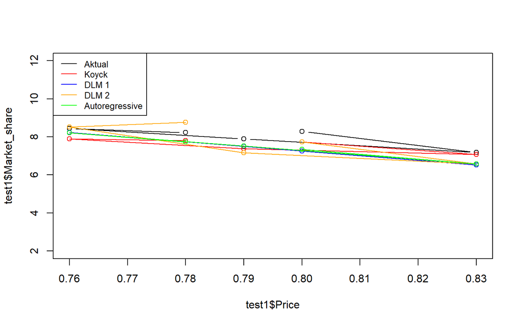

```r
par(mfrow=c(1,1))  # atur layout grafik tunggal

# plot data aktual
plot(test1$Price, test1$Market_share, type="b", col="black", ylim=c(2,12))

# tambahkan garis ramalan dari masing-masing model
points(test1$Price, fore1.koyck$forecasts, col="red");   lines(test1$Price, fore1.koyck$forecasts, col="red")
points(test1$Price, fore1.dlm$forecasts, col="blue");    lines(test1$Price, fore1.dlm$forecasts, col="blue")
points(test1$Price, fore1.dlm2$forecasts, col="orange"); lines(test1$Price, fore1.dlm2$forecasts, col="orange")
points(test1$Price, fore1.ardl$forecasts, col="green");  lines(test1$Price, fore1.ardl$forecasts, col="green")

# legenda model
legend("topleft",
       c("Aktual", "Koyck","DLM 1","DLM 2", "Autoregressive"),
       lty=1, col=c("black","red","blue","orange","green"), cex=0.8)
```

# Distributed Lag Data 2 (Sales ~ Advertising)

## Pembagian Data

```r
#SPLIT DATA
n2 <- nrow(data2)
n2.train <- round(0.75 * n2)

train2 <- data2[1:n2.train, ]
test2  <- data2[(n2.train + 1):n2, ]
```

```r
#data time series
train2.ts <- ts(train2)
test2.ts  <- ts(test2)
data2.ts  <- ts(data2)
```

## Model Koyck

### Pemodelan

```r
#MODEL KOYCK
model2.koyck <- koyckDlm(x = train2$Advertising, y = train2$Sales)
summary(model2.koyck)
```

```
##
## Call:
## "Y ~ (Intercept) + Y.1 + X.t"
##
## Residuals:
##       Min        1Q    Median        3Q       Max
## -0.265890 -0.120691 -0.005297  0.107270  0.267226
##
## Coefficients:
##             Estimate Std. Error t value Pr(>|t|)
## (Intercept)  1.61369    0.38958   4.142 0.000322 ***
## Y.1          0.74280    0.09797   7.582 4.77e-08 ***
## X.t          0.19436    0.08585   2.264 0.032152 *
## ---
## Signif. codes:  0 '***' 0.001 '**' 0.01 '*' 0.05 '.' 0.1 ' ' 1
##
## Residual standard error: 0.156 on 26 degrees of freedom
## Multiple R-Squared: 0.9954,  Adjusted R-squared: 0.995
## Wald test:  2796 on 2 and 26 DF,  p-value: < 2.2e-16
##
## Diagnostic tests:
## NULL
##
##                             alpha      beta       phi
## Geometric coefficients:  6.274186 0.1943614 0.7428042
```

```r
AIC(model2.koyck)
```

```
## [1] -20.60961
```

```r
BIC(model2.koyck)
```

```
## [1] -15.14043
```

### Peramalan dan Akurasi

```r
fore2.koyck <- forecast(model = model2.koyck, x = test2$Advertising, h = nrow(test2))
fore2.koyck
```

```
## $forecasts
##  [1] 19.73293 19.94483 20.16054 20.47626 20.71077 20.94328 21.13542 21.39476
##  [9] 21.68459 22.01648
##
## $call
## forecast.koyckDlm(model = model2.koyck, x = test2$Advertising,
##     h = nrow(test2))
##
## attr(,"class")
## [1] "forecast.koyckDlm" "dLagM"
```

```r
mape2.koyck <- MAPE(fore2.koyck$forecasts, test2$Sales)
mape2.koyck #data test
```

```
## [1] 0.04712769
```

```r
#akurasi data training
GoF(model2.koyck)
```

```
##               n       MAE           MPE        MAPE       sMAPE      MASE
## model2.koyck 29 0.1219025 -0.0001551597 0.007579302 0.007579911 0.4213914
##                     MSE     MRAE     GMRAE
## model2.koyck 0.02183119 70715208 0.5994542
```

## Regression with Distributed Lag

### Pemodelan (Lag=2)

```r
model2.dlm <- dlm(x = train2$Advertising, y = train2$Sales, q = 2)
summary(model2.dlm)
```

```
##
## Call:
## lm(formula = model.formula, data = design)
##
## Residuals:
##      Min       1Q   Median       3Q      Max
## -0.49181 -0.15731 -0.00976  0.15782  0.48554
##
## Coefficients:
##             Estimate Std. Error t value Pr(>|t|)
## (Intercept)   4.9621     0.3453  14.369 2.76e-13 ***
## x.t           0.1654     0.2362   0.700    0.490
## x.1           0.4118     0.3036   1.356    0.188
## x.2           0.2365     0.2299   1.028    0.314
## ---
## Signif. codes:  0 '***' 0.001 '**' 0.01 '*' 0.05 '.' 0.1 ' ' 1
##
## Residual standard error: 0.2644 on 24 degrees of freedom
## Multiple R-squared:  0.9857, Adjusted R-squared:  0.9839
## F-statistic: 550.5 on 3 and 24 DF,  p-value: < 2.2e-16
##
## AIC and BIC values for the model:
##        AIC     BIC
## 1 10.65158 17.3126
```

```r
AIC(model2.dlm)
```

```
## [1] 10.65158
```

```r
BIC(model2.dlm)
```

```
## [1] 17.3126
```

Dari hasil di atas, dapat dilihat peubah mana saja yang berpengaruh signifikan terhadap $y$ berdasarkan nilai $P-value < 0.05$. Adapun model keseluruhan yang terbentuk adalah sebagai berikut

$$\hat{Y_t}=4.9621+0.16541X_t+0.4118X_{t-1}+0.2365X_{t-2}$$

### Peramalan dan Akurasi

```r
fore2.dlm <- forecast(model = model2.dlm, x = test2$Advertising, h = nrow(test2))
fore2.dlm
```

```
## $forecasts
##  [1] 20.00000 20.16273 20.34199 20.64514 21.04549 21.28427 21.42434 21.63570
##  [9] 21.98911 22.43611
##
## $call
## forecast.dlm(model = model2.dlm, x = test2$Advertising, h = nrow(test2))
##
## attr(,"class")
## [1] "forecast.dlm" "dLagM"
```

```r
mape2.dlm <- MAPE(fore2.dlm$forecasts, test2$Sales)
mape2.dlm
```

```
## [1] 0.06098542
```

```r
#akurasi data training
GoF(model2.dlm)
```

```
##             n       MAE          MPE       MAPE      sMAPE      MASE       MSE
## model2.dlm 28 0.1974215 -0.000441056 0.01227844 0.01226426 0.6833821 0.0599283
##                MRAE   GMRAE
## model2.dlm 24356741 1.03794
```

### *Lag* Optimum

```r
#penentuan lag optimum
finiteDLMauto(formula = Sales ~ Advertising,
              data = data.frame(train2), q.min = 1, q.max = 10,
              model.type = "dlm", error.type = "AIC", trace = TRUE)
```

```
##    q - k    MASE       AIC      BIC   GMRAE    MBRAE R.Adj.Sq    Ljung-Box
## 9      9 0.34922 -12.64945 -0.11518 0.71868 -0.27524  0.98552 0.3688121825
## 10    10 0.35122  -9.22038  3.72414 0.74801  0.01543  0.98048 0.5004571650
## 8      8 0.36932  -7.82507  4.17639 0.60573 -0.47218  0.98440 0.2257284249
## 7      7 0.46948  -0.95390 10.40104 0.97231 -0.34671  0.98142 0.0833971793
## 6      6 0.53634   2.13689 12.73938 0.98902  0.54574  0.98158 0.0129631654
## 5      5 0.59715   4.21576 13.96677 1.25981 -0.65144  0.98222 0.0011054100
## 4      4 0.61259   6.97647 15.78315 1.09895  0.31802  0.98250 0.0011522571
## 3      3 0.64397   7.56299 15.33801 1.10105  0.25684  0.98393 0.0002577476
## 2      2 0.68338  10.65158 17.31260 1.03794 -1.84527  0.98389 0.0001971192
## 1      1 0.75787  12.80053 18.26971 1.20511  0.38642  0.98424 0.0000340988
```

Berdasarkan output tersebut, lag optimum didapatkan ketika lag=9. Selanjutnya dilakukan pemodelan untuk lag=9

```r
#model dlm dengan lag optimum (ganti angka q sesuai hasil di atas)
model2.dlm2 <- dlm(x = train2$Advertising, y = train2$Sales, q = 9)
summary(model2.dlm2)
```

```
##
## Call:
## lm(formula = model.formula, data = design)
##
## Residuals:
##       Min        1Q    Median        3Q       Max
## -0.179388 -0.072603 -0.001433  0.069828  0.196265
##
## Coefficients:
##             Estimate Std. Error t value Pr(>|t|)
## (Intercept)  4.74862    0.88348   5.375 0.000312 ***
## x.t          0.26810    0.16590   1.616 0.137164
## x.1          0.40494    0.21261   1.905 0.085962 .
## x.2          0.07401    0.20313   0.364 0.723193
## x.3          0.12845    0.20922   0.614 0.552948
## x.4          0.03926    0.17930   0.219 0.831093
## x.5          0.31855    0.18476   1.724 0.115409
## x.6          0.07760    0.18616   0.417 0.685600
## x.7         -0.05187    0.20632  -0.251 0.806593
## x.8         -0.19628    0.21305  -0.921 0.378592
## x.9         -0.27306    0.18475  -1.478 0.170195
## ---
## Signif. codes:  0 '***' 0.001 '**' 0.01 '*' 0.05 '.' 0.1 ' ' 1
##
## Residual standard error: 0.1465 on 10 degrees of freedom
## Multiple R-squared:  0.9928, Adjusted R-squared:  0.9855
## F-statistic: 137.1 on 10 and 10 DF,  p-value: 2.447e-09
##
## AIC and BIC values for the model:
##         AIC        BIC
## 1 -12.64945 -0.1151781
```

```r
AIC(model2.dlm2)
```

```
## [1] -12.64945
```

```r
BIC(model2.dlm2)
```

```
## [1] -0.1151781
```

Dari hasil tersebut dapat dilihat peubah mana saja yang berpengaruh signifikan terhadap taraf nyata 5%. Adapun keseluruhan model yang terbentuk mengikuti bentuk umum model distributed lag dengan lag 9.

Adapun hasil peramalan 10 periode ke depan menggunakan model tersebut adalah sebagai berikut

```r
#peramalan dan akurasi
fore2.dlm2 <- forecast(model = model2.dlm2, x = test2$Advertising, h = nrow(test2))

#akurasi data test
mape2.dlm2 <- MAPE(fore2.dlm2$forecasts, test2$Sales)
mape2.dlm2
```

```
## [1] 0.06056547
```

```r
#akurasi data training
GoF(model2.dlm2)
```

```
##              n        MAE          MPE        MAPE       sMAPE      MASE
## model2.dlm2 21 0.08381306 -4.52648e-05 0.004759537 0.004759903 0.3492211
##                    MSE     MRAE     GMRAE
## model2.dlm2 0.01022327 53304425 0.7186822
```

## Model Autoregressive

### Pemodelan

```r
model2.ardl <- ardlDlm(formula = Sales ~ Advertising,
                        data = train2, p = 1, q = 1)
summary(model2.ardl)
```

```
##
## Time series regression with "ts" data:
## Start = 2, End = 30
##
## Call:
## dynlm(formula = as.formula(model.text), data = data)
##
## Residuals:
##       Min        1Q    Median        3Q       Max
## -0.229277 -0.127437  0.009143  0.109228  0.259132
##
## Coefficients:
##               Estimate Std. Error t value Pr(>|t|)
## (Intercept)    1.55786    0.44353   3.512  0.00171 **
## Advertising.t  0.29110    0.13707   2.124  0.04376 *
## Advertising.1 -0.09584    0.16067  -0.596  0.55621
## Sales.1        0.74360    0.09964   7.463 8.14e-08 ***
## ---
## Signif. codes:  0 '***' 0.001 '**' 0.01 '*' 0.05 '.' 0.1 ' ' 1
##
## Residual standard error: 0.1576 on 25 degrees of freedom
## Multiple R-squared:  0.9955, Adjusted R-squared:  0.9949
## F-statistic:  1830 on 3 and 25 DF,  p-value: < 2.2e-16
```

```r
AIC(model2.ardl)
```

```
## [1] -19.18177
```

```r
BIC(model2.ardl)
```

```
## [1] -12.34529
```

Hasil di atas menunjukkan bahwa selain peubah $x_{t-1}$, hasil uji t menunjukkan nilai-p pada peubah $<0.05$ Hal ini menunjukkan bahwa peubah $x_{t}, Y_{t-1},$ berpengaruh signifikan terhadap $y_t$, sementara $x_{t-1}$ tidak berpengaruh signifikan terhadap $y_t$. Model keseluruhannya adalah sebagai berikut:

$$\hat{Y}=1.55786+0.29110X_t-0.09584X_{t-1}+0.74360Y_{t-1}$$

### Peramalan dan Akurasi

```r
fore2.ardl <- forecast(model = model2.ardl, x = test2$Advertising, h = nrow(test2))
fore2.ardl
```

```
## $forecasts
##  [1] 19.72862 19.93768 20.16129 20.53170 20.73047 20.96560 21.14081 21.43616
##  [9] 21.74384 22.09937
##
## $call
## forecast.ardlDlm(model = model2.ardl, x = test2$Advertising,
##     h = nrow(test2))
##
## attr(,"class")
## [1] "forecast.ardlDlm" "dLagM"
```

```r
mape2.ardl <- MAPE(fore2.ardl$forecasts, test2$Sales)
mape2.ardl
```

```
## [1] 0.0484832
```

```r
#akurasi data training
GoF(model2.ardl)
```

```
##              n       MAE           MPE        MAPE       sMAPE      MASE
## model2.ardl 29 0.1238592 -0.0001484019 0.007696613 0.007697173 0.4281553
##                   MSE     MRAE     GMRAE
## model2.ardl 0.0214047 81884782 0.7548444
```

### *Lag* Optimum

```r
#penentuan lag optimum
model2.ardl.opt <- ardlBoundOrders(data = data.frame(data2), ic = "AIC",
                                    formula = Sales ~ Advertising)
model2.ardl.opt
```

```
## $p
##   Advertising
## 1           4
##
## $q
## [1] 15
##
## $Stat.table
##             q = 1      q = 2      q = 3       q = 4        q = 5      q = 6
## p = 1  -15.008746 -11.952031 -11.702811 -10.4556102   -7.4743459 -10.190508
## p = 2  -13.773954 -12.129560 -11.273832  -9.7873186   -6.6233481  -8.740430
## p = 3   -8.848612  -8.848612 -12.443867 -10.3937201   -7.1398397  -9.693082
## p = 4  -12.022451 -10.663941 -10.663941  -8.6692457   -5.3883982  -8.000189
## p = 5   -6.455663  -4.517684  -6.129877  -6.1298773   -5.8218760  -9.506366
## p = 6  -11.513095  -9.679368 -10.603965  -8.7469140   -8.7469140  -8.630625
## p = 7   -5.508868  -3.728014  -6.010216  -4.5325635  -12.0788009 -12.078801
## p = 8   -8.927789  -7.599283  -5.788882  -4.6394213  -11.9646171 -10.910332
## p = 9   -5.602665  -3.769155  -2.219895  -0.2595925   -9.1716507  -7.295497
## p = 10  -9.465550  -7.587108  -5.720971  -3.8196288   -8.1361157  -6.288259
## p = 11   1.701332   2.523049   3.963660   5.8214473   -0.1570961   1.564017
## p = 12  -6.976292  -6.760264  -4.921983  -7.0600636   -9.0408197  -8.605279
## p = 13  -1.534882  -4.200569  -6.944121  -5.0254590  -32.2884029 -46.908793
## p = 14  -3.660390  -1.761109  -2.219038  -3.7538496 -198.9302277         NA
## p = 15 -11.707853 -17.884028 -17.585602          NA           NA         NA
##             q = 7      q = 8        q = 9      q = 10       q = 11     q = 12
## p = 1   -7.624070  -8.686449   -4.7462387 -3.32746110   -2.9869318 -0.9555962
## p = 2   -5.806960  -7.921509   -4.2989938 -2.59233785   -1.1348530  0.3798720
## p = 3   -6.091044  -7.142078   -4.2143900 -1.64141900   -0.2764654  2.0637751
## p = 4   -4.274001  -5.164970   -2.2163924 -0.02517076    0.1775901  3.0432639
## p = 5   -5.454353  -5.301255   -1.9990132  0.94455082    1.2370098  2.5673773
## p = 6   -4.511772  -3.986967   -0.7254173  2.14054832    2.0257425  0.1204914
## p = 7  -13.506180 -11.580354   -7.7220728 -3.84200566   -3.0518769 -4.1223494
## p = 8  -10.910332  -9.645933   -5.8154895 -2.15509138   -2.0247232 -3.0170743
## p = 9   -6.993088  -6.993088   -5.9083235 -2.05781567   -0.3245455 -1.0178440
## p = 10  -7.323609  -8.441982   -8.4419817 -8.92421877   -7.3319735 -5.7824865
## p = 11  -1.509374  -6.042816   -9.7853072 -9.78530724 -121.6529036         NA
## p = 12  -6.819227 -19.795453 -125.1056421          NA           NA         NA
## p = 13 -93.617891         NA           NA          NA           NA         NA
## p = 14         NA         NA           NA          NA           NA         NA
## p = 15         NA         NA           NA          NA           NA         NA
##            q = 13     q = 14     q = 15
## p = 1    2.983211   2.566813  -17.54638
## p = 2    3.581183   4.065066  -76.93283
## p = 3    5.505343   5.691237  -97.73207
## p = 4    6.600634   6.567285 -305.75496
## p = 5    5.541829  -6.747419         NA
## p = 6   -4.715695 -94.241328         NA
## p = 7  -42.546289         NA         NA
## p = 8  -47.628148         NA         NA
## p = 9          NA         NA         NA
## p = 10         NA         NA         NA
## p = 11         NA         NA         NA
## p = 12         NA         NA         NA
## p = 13         NA         NA         NA
## p = 14         NA         NA         NA
## p = 15         NA         NA         NA
##
## $min.Stat
## [1] -305.755
```

```r
min_p2 <- c()
for (i in 1:6) {
  min_p2[i] <- min(model2.ardl.opt$Stat.table[[i]])
}
q2_opt <- which(min_p2 == min(min_p2, na.rm = TRUE))
p2_opt <- which(model2.ardl.opt$Stat.table[[q2_opt]] ==
                  min(model2.ardl.opt$Stat.table[[q2_opt]], na.rm = TRUE))
data.frame("q_optimum" = q2_opt, "p_optimum" = p2_opt,
           "AIC" = model2.ardl.opt$min.Stat)
```

```
##   q_optimum p_optimum      AIC
## 1         2        15 -305.755
```

## Pemodelan DLM & ARDL dengan Library `dynlm`

```r
#sama dengan model dlm q=1
cons_lm5 <- dynlm(Sales ~ Advertising + L(Advertising), data = train2.ts)

#sama dengan model ardl p=1 q=0
cons_lm6 <- dynlm(Sales ~ Advertising + L(Sales), data = train2.ts)

#sama dengan ardl p=1 q=1
cons_lm7 <- dynlm(Sales ~ Advertising + L(Advertising) + L(Sales), data = train2.ts)

#sama dengan dlm q=2
cons_lm8 <- dynlm(Sales ~ Advertising + L(Advertising) + L(Advertising, 2), data = train2.ts)
```

### Ringkasan Model

```r
summary(cons_lm5)
```

```
##
## Time series regression with "ts" data:
## Start = 2, End = 30
##
## Call:
## dynlm(formula = Sales ~ Advertising + L(Advertising), data = train2.ts)
##
## Residuals:
##      Min       1Q   Median       3Q      Max
## -0.45641 -0.21066  0.03391  0.20084  0.43319
##
## Coefficients:
##                Estimate Std. Error t value Pr(>|t|)
## (Intercept)      4.5932     0.3117  14.738 3.89e-14 ***
## Advertising      0.2796     0.2415   1.158    0.257
## L(Advertising)   0.5510     0.2383   2.312    0.029 *
## ---
## Signif. codes:  0 '***' 0.001 '**' 0.01 '*' 0.05 '.' 0.1 ' ' 1
##
## Residual standard error: 0.2776 on 26 degrees of freedom
## Multiple R-squared:  0.9854, Adjusted R-squared:  0.9842
## F-statistic: 875.4 on 2 and 26 DF,  p-value: < 2.2e-16
```

```r
summary(cons_lm6)
```

```
##
## Time series regression with "ts" data:
## Start = 2, End = 30
##
## Call:
## dynlm(formula = Sales ~ Advertising + L(Sales), data = train2.ts)
##
## Residuals:
##       Min        1Q    Median        3Q       Max
## -0.241256 -0.124752  0.008004  0.121297  0.272373
##
## Coefficients:
##             Estimate Std. Error t value Pr(>|t|)
## (Intercept)  1.71947    0.34678   4.958 3.75e-05 ***
## Advertising  0.22200    0.07235   3.068  0.00498 **
## L(Sales)     0.71154    0.08285   8.588 4.56e-09 ***
## ---
## Signif. codes:  0 '***' 0.001 '**' 0.01 '*' 0.05 '.' 0.1 ' ' 1
##
## Residual standard error: 0.1556 on 26 degrees of freedom
## Multiple R-squared:  0.9954, Adjusted R-squared:  0.995
## F-statistic:  2814 on 2 and 26 DF,  p-value: < 2.2e-16
```

```r
summary(cons_lm7)
```

```
##
## Time series regression with "ts" data:
## Start = 2, End = 30
##
## Call:
## dynlm(formula = Sales ~ Advertising + L(Advertising) + L(Sales),
##     data = train2.ts)
##
## Residuals:
##       Min        1Q    Median        3Q       Max
## -0.229277 -0.127437  0.009143  0.109228  0.259132
##
## Coefficients:
##                Estimate Std. Error t value Pr(>|t|)
## (Intercept)     1.55786    0.44353   3.512  0.00171 **
## Advertising     0.29110    0.13707   2.124  0.04376 *
## L(Advertising) -0.09584    0.16067  -0.596  0.55621
## L(Sales)        0.74360    0.09964   7.463 8.14e-08 ***
## ---
## Signif. codes:  0 '***' 0.001 '**' 0.01 '*' 0.05 '.' 0.1 ' ' 1
##
## Residual standard error: 0.1576 on 25 degrees of freedom
## Multiple R-squared:  0.9955, Adjusted R-squared:  0.9949
## F-statistic:  1830 on 3 and 25 DF,  p-value: < 2.2e-16
```

```r
summary(cons_lm8)
```

```
##
## Time series regression with "ts" data:
## Start = 3, End = 30
##
## Call:
## dynlm(formula = Sales ~ Advertising + L(Advertising) + L(Advertising,
##     2), data = train2.ts)
##
## Residuals:
##      Min       1Q   Median       3Q      Max
## -0.49181 -0.15731 -0.00976  0.15782  0.48554
##
## Coefficients:
##                   Estimate Std. Error t value Pr(>|t|)
## (Intercept)         4.9621     0.3453  14.369 2.76e-13 ***
## Advertising         0.1654     0.2362   0.700    0.490
## L(Advertising)      0.4118     0.3036   1.356    0.188
## L(Advertising, 2)   0.2365     0.2299   1.028    0.314
## ---
## Signif. codes:  0 '***' 0.001 '**' 0.01 '*' 0.05 '.' 0.1 ' ' 1
##
## Residual standard error: 0.2644 on 24 degrees of freedom
## Multiple R-squared:  0.9857, Adjusted R-squared:  0.9839
## F-statistic: 550.5 on 3 and 24 DF,  p-value: < 2.2e-16
```

### SSE

```r
deviance(cons_lm5)
```

```
## [1] 2.003617
```

```r
deviance(cons_lm6)
```

```
## [1] 0.6295707
```

```r
deviance(cons_lm7)
```

```
## [1] 0.6207363
```

```r
deviance(cons_lm8)
```

```
## [1] 1.677992
```

### Uji encomptest

```r
#uji model
if (require("lmtest")) encomptest(cons_lm5, cons_lm6)
```

```
## Encompassing test
##
## Model 1: Sales ~ Advertising + L(Advertising)
## Model 2: Sales ~ Advertising + L(Sales)
## Model E: Sales ~ Advertising + L(Advertising) + L(Sales)
##           Res.Df Df       F    Pr(>F)
## M1 vs. ME     25 -1 55.6952 8.144e-08 ***
## M2 vs. ME     25 -1  0.3558    0.5562
## ---
## Signif. codes:  0 '***' 0.001 '**' 0.01 '*' 0.05 '.' 0.1 ' ' 1
```

#### Uji Autokorelasi Residual

```r
#durbin watson
dwtest(cons_lm5)
```

```
##
##  Durbin-Watson test
##
## data:  cons_lm5
## DW = 0.37269, p-value = 1.393e-09
## alternative hypothesis: true autocorrelation is greater than 0
```

```r
dwtest(cons_lm6)
```

```
##
##  Durbin-Watson test
##
## data:  cons_lm6
## DW = 1.8706, p-value = 0.2357
## alternative hypothesis: true autocorrelation is greater than 0
```

```r
dwtest(cons_lm7)
```

```
##
##  Durbin-Watson test
##
## data:  cons_lm7
## DW = 1.9917, p-value = 0.3507
## alternative hypothesis: true autocorrelation is greater than 0
```

```r
dwtest(cons_lm8)
```

```
##
##  Durbin-Watson test
##
## data:  cons_lm8
## DW = 0.45322, p-value = 5.492e-08
## alternative hypothesis: true autocorrelation is greater than 0
```

#### Uji Heterogenitas

```r
bptest(cons_lm5)
```

```
##
##  studentized Breusch-Pagan test
##
## data:  cons_lm5
## BP = 0.29867, df = 2, p-value = 0.8613
```

```r
bptest(cons_lm6)
```

```
##
##  studentized Breusch-Pagan test
##
## data:  cons_lm6
## BP = 0.12148, df = 2, p-value = 0.9411
```

```r
bptest(cons_lm7)
```

```
##
##  studentized Breusch-Pagan test
##
## data:  cons_lm7
## BP = 0.66214, df = 3, p-value = 0.8821
```

```r
bptest(cons_lm8)
```

```
##
##  studentized Breusch-Pagan test
##
## data:  cons_lm8
## BP = 3.1875, df = 3, p-value = 0.3636
```

didaptkan nilai p-value > 0.05 → tidak ada heteroskedastisitas

#### Uji Normalitas

H0: Residual berdistribusi normal.

H1: Residual tidak berdistribusi normal.

```r
shapiro.test(residuals(cons_lm5))
```

```
##
##  Shapiro-Wilk normality test
##
## data:  residuals(cons_lm5)
## W = 0.94714, p-value = 0.1542
```

```r
shapiro.test(residuals(cons_lm6))
```

```
##
##  Shapiro-Wilk normality test
##
## data:  residuals(cons_lm6)
## W = 0.95861, p-value = 0.3036
```

```r
shapiro.test(residuals(cons_lm7))
```

```
##
##  Shapiro-Wilk normality test
##
## data:  residuals(cons_lm7)
## W = 0.95502, p-value = 0.2466
```

```r
shapiro.test(residuals(cons_lm8))
```

```
##
##  Shapiro-Wilk normality test
##
## data:  residuals(cons_lm8)
## W = 0.98152, p-value = 0.8851
```

didapatkan nilai p-value > 0.05 → gagal tolak H0 → residual normal.

## Perbandingan Model

```r
akurasi2 <- matrix(c(mape2.koyck, mape2.dlm, mape2.dlm2, mape2.ardl))
row.names(akurasi2) <- c("Koyck", "DLM 1", "DLM 2", "Autoregressive")
colnames(akurasi2) <- c("MAPE")
akurasi2
```

```
##                      MAPE
## Koyck          0.04712769
## DLM 1          0.06098542
## DLM 2          0.06056547
## Autoregressive 0.04848320
```

Berdasarkan nilai MAPE, model paling optimum didapat pada Model Koyck karena memiliki nilai MAPE yang terkecil.

### Plot

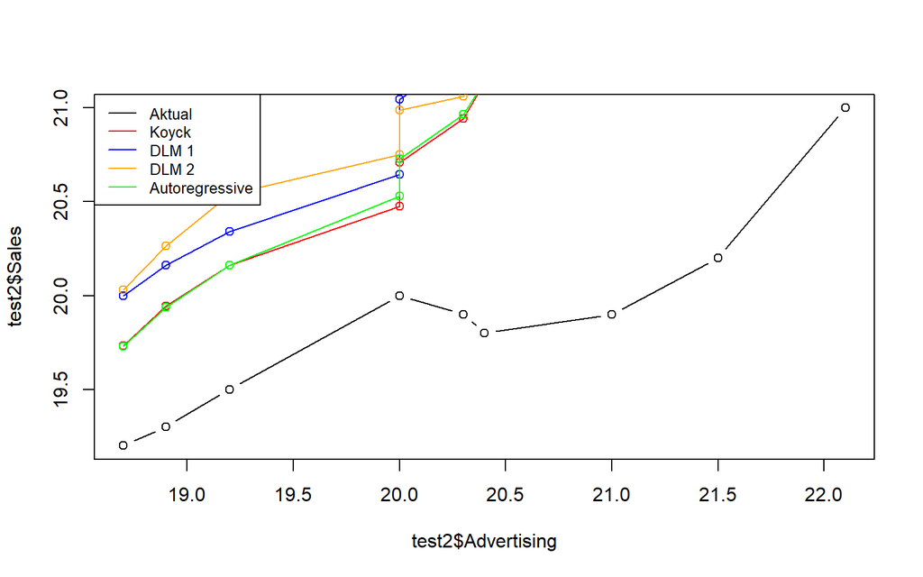

```r
par(mfrow = c(1, 1))  # atur layout grafik tunggal

# plot data aktual
plot(test2$Advertising, test2$Sales, type = "b", col = "black")

# tambahkan garis ramalan dari masing-masing model
points(test2$Advertising, fore2.koyck$forecasts, col = "red");   lines(test2$Advertising, fore2.koyck$forecasts, col = "red")
points(test2$Advertising, fore2.dlm$forecasts, col = "blue");    lines(test2$Advertising, fore2.dlm$forecasts, col = "blue")
points(test2$Advertising, fore2.dlm2$forecasts, col = "orange"); lines(test2$Advertising, fore2.dlm2$forecasts, col = "orange")
points(test2$Advertising, fore2.ardl$forecasts, col = "green");  lines(test2$Advertising, fore2.ardl$forecasts, col = "green")

# legenda model
legend("topleft",
       c("Aktual", "Koyck", "DLM 1", "DLM 2", "Autoregressive"),
       lty = 1, col = c("black", "red", "blue", "orange", "green"), cex = 0.8)
```